# Clean ‘Removal’ data

indra deCastro

12 abril, 2018

## Import data

```r
raw <- read.table("data/removal.csv", header=T, sep=",", na.strings=c("-", "N/A", "NA"))
```

## Check for table consistency

i.e. check for: Number of Sites? number of treatments? number of experimental units?…  
Number of sites: 38

```
## $codigo_parcela
##
## ARG01Ext ARG01Int AUS01Ext AUS01Int AUS02Ext AUS02Int BEL01Ext BEL01Int
##       15       15       15       15       15       15       15       15
## BRA01Ext BRA01Int BRA02Ext BRA02Int BRA03Ext BRA03Int CAN01Ext CAN01Int
##       15       15       15       15       15       15       15       15
## CHI01Ext CHI01Int COL01Ext COL01Int COL02Ext COL02Int COL03Ext COL03Int
##       15       15       15       15       15       15       15       15
## ECU01Ext ECU01Int ECU02Ext ECU02Int ENG01Ext ENG01Int FRA01Ext FRA01Int
##       15       15       15       15       15       15       15       15
## GER01Ext GER01Int HUN01Ext HUN01Int IND01Ext IND01Int IRA01Ext IRA01Int
##       15       15       15       15       15       15       15       15
## ITA01Ext ITA01Int MEX01Ext MEX01Int MEX02Ext MEX02Int MEX03Ext MEX03Int
##       15       15       15       15       15       15       15       15
## MEX04Ext MEX04Int MEX05Ext MEX05Int MEX06Ext MEX06Int POR01Ext POR01Int
##       15       15       15       15       15       15       15       15
## SAL01Ext SAL01Int SOU01Ext SOU01Int SPA01Ext SPA01Int SPA02Ext SPA02Int
##       15       15       15       15       15       15       15       15
## TUR01Ext TUR01Int USA01Ext USA01Int VEN01Ext VEN01Int WAL01Ext WAL01Int
##       15       15       15       15       15       15       15       15
## WAL02Ext WAL02Int WAL03Ext WAL03Int
##       15       15       15       15
##
## $manejo
##
## Ext Int
## 570 570
##
## $unidad
##
## Cont  Exp
##  380  760
##
## $no_unidad
##
##   1  10   2   3   4   5   6   7   8   9
## 152  76 152 152 152 152  76  76  76  76
```

```r
raw$manejo <- factor(raw$manejo, labels=c("Int", "Ext"))
table(raw$manejo)
```

```
##
## Int Ext
## 570 570
```

## Explore data

i.e. check for: ranges of data make sense? no evident outliers? number of NA values?…

```
##   initial_dung   final_dung_wet  final_dung_dry   cont_dung_dry
##  Min.   :284.7   Min.   :  0.0   Min.   :  0.00   Min.   : 32.50
##  1st Qu.:300.0   1st Qu.:139.5   1st Qu.: 38.98   1st Qu.: 44.23
##  Median :300.0   Median :196.7   Median : 49.20   Median : 50.24
##  Mean   :300.8   Mean   :187.4   Mean   : 52.80   Mean   : 63.89
##  3rd Qu.:300.3   3rd Qu.:240.9   3rd Qu.: 60.98   3rd Qu.: 69.63
##  Max.   :323.5   Max.   :306.5   Max.   :160.17   Max.   :236.13
##  NA's   :8       NA's   :27      NA's   :26       NA's   :270
##    paper_bag      dry_paper_bag
##  Min.   : 0.970   Min.   : 0.900
##  1st Qu.: 4.940   1st Qu.: 5.000
##  Median : 6.770   Median : 6.370
##  Mean   : 8.688   Mean   : 9.069
##  3rd Qu.:14.557   3rd Qu.: 9.000
##  Max.   :26.100   Max.   :54.890
##  NA's   :150      NA's   :390
```

Summarize percentage of NAs in each variable:

```
##                perc.NAs
## initial_dung       0.70
## final_dung_wet     2.37
## final_dung_dry     2.28
## cont_dung_dry     23.68
## paper_bag         13.16
## dry_paper_bag     34.21
```

### All variables

```
##   initial_dung   final_dung_wet  final_dung_dry   cont_dung_dry
##  Min.   :284.7   Min.   :  0.0   Min.   :  0.00   Min.   : 32.50
##  1st Qu.:300.0   1st Qu.:139.5   1st Qu.: 38.98   1st Qu.: 44.23
##  Median :300.0   Median :196.7   Median : 49.20   Median : 50.24
##  Mean   :300.8   Mean   :187.4   Mean   : 52.80   Mean   : 63.89
##  3rd Qu.:300.3   3rd Qu.:240.9   3rd Qu.: 60.98   3rd Qu.: 69.63
##  Max.   :323.5   Max.   :306.5   Max.   :160.17   Max.   :236.13
##  NA's   :8       NA's   :27      NA's   :26       NA's   :270
##    paper_bag      dry_paper_bag
##  Min.   : 0.970   Min.   : 0.900
##  1st Qu.: 4.940   1st Qu.: 5.000
##  Median : 6.770   Median : 6.370
##  Mean   : 8.688   Mean   : 9.069
##  3rd Qu.:14.557   3rd Qu.: 9.000
##  Max.   :26.100   Max.   :54.890
##  NA's   :150      NA's   :390
```

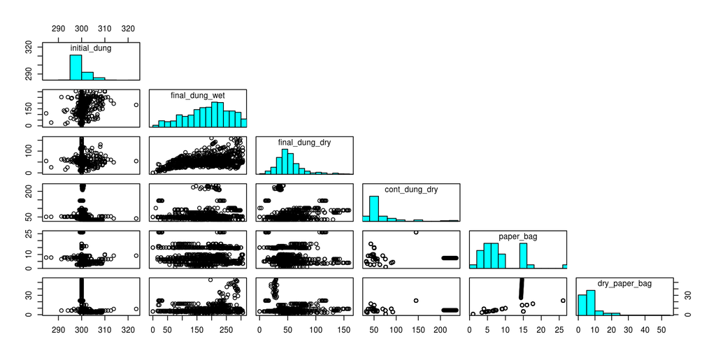

### Dry variables

Moreover,  
The variable “dry_paper_bag”  
50.89, 51.89, 52.89, 53.89, 54.89, 40.89, 41.89, 42.89, 43.89, 44.89, 45.89, 46.89, 47.89, 48.89, 49.89, 35.89, 36.89, 37.89, 38.89, 39.89, 25.89, 26.89, 27.89, 28.89, 29.89, 30.89, 31.89, 32.89, 33.89, 34.89, 21.7, 21.7, 21.7, 21.7, 21.7, 21.7, 21.7, 21.7, 21.7, 21.7, 21.7, 21.7, 21.7, 21.7, 21.7, 21.7, 21.7, 21.7, 21.7, 21.7, 21.7, 21.7, 21.7, 21.7, 21.7, 21.7, 21.7, 21.7, 21.7, 21.7  
and “cont_dung_dry” have a problem:  
232.13, 233.13, 234.13, 235.13, 236.13, 222.13, 223.13, 224.13, 225.13, 226.13, 227.13, 228.13, 229.13, 230.13, 231.13, 217.13, 218.13, 219.13, 220.13, 221.13, 207.13, 208.13, 209.13, 210.13, 211.13, 212.13, 213.13, 214.13, 215.13, 216.13  
Most probably it is due to dragging the initial value (25.89 and 207.13) in Excel to complete the other values.  
However, this 207.13gr seems an outlier for that variable.  
**Is this possible?** Might it be 20.713 ??

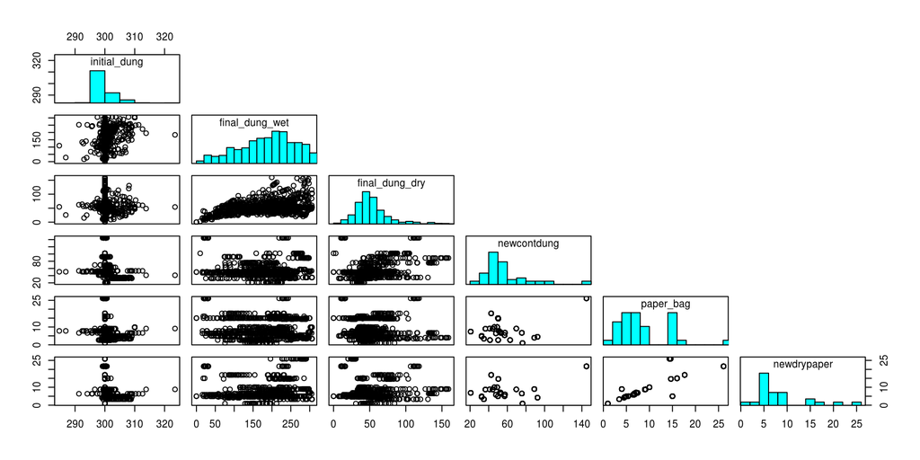

### Initial dung

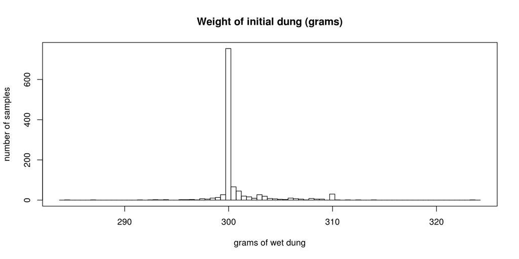

```
##
## smaller   300gr  bigger
##      86     716     330
```

### Final dung (wet)

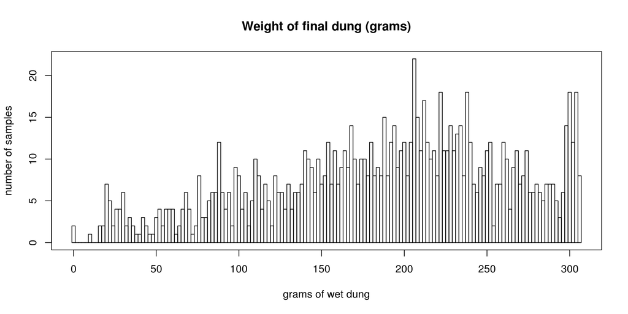

## METHOD 1

The complete removal formula is:  
*Removal rate = (ExpIniWet - (ExpFinWet + WaterLoss)) / 48h*  
Where *WaterLoss* is calculated as *ConIniWet - ConFinWet* using the control experiments.

### Water loss (evaporation in control experiments)

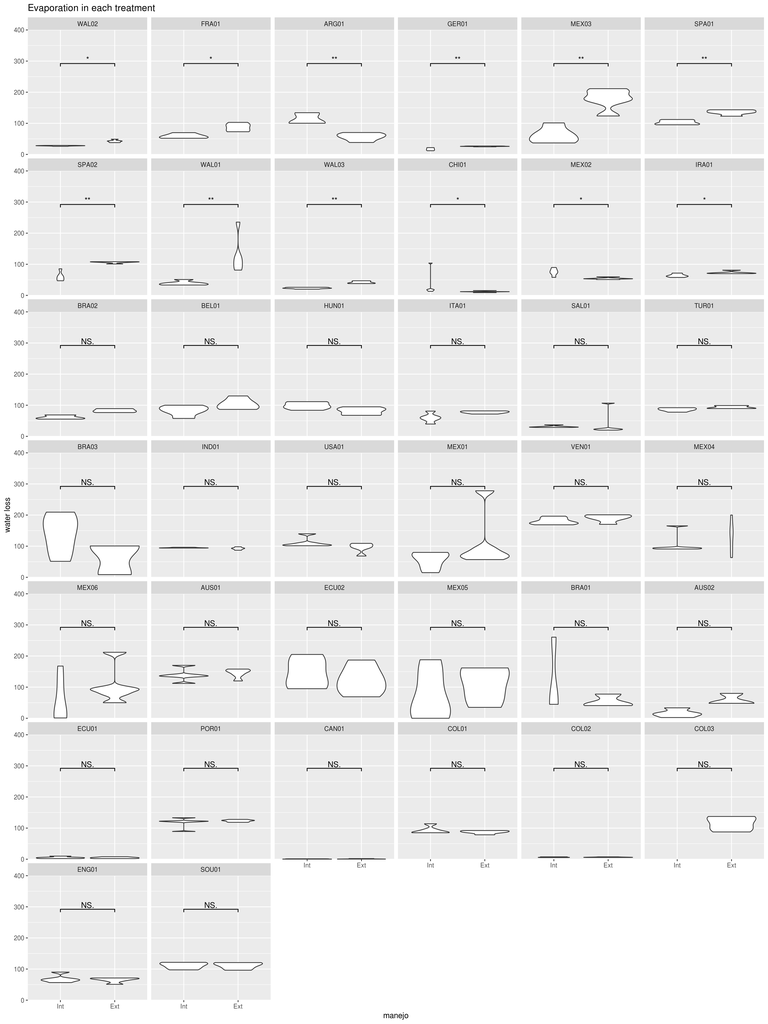

Note that the water loss is different (wilcoxon test) between **31.58%** Intensive and Extensive treatments.  
**Is this reasonable??**  
Are there important habitat differences between Intensive and Extensive treatments?  
**Where Control experiments really beetle-free??**

### Removal rate

Are these observations of simple dung difference correct?

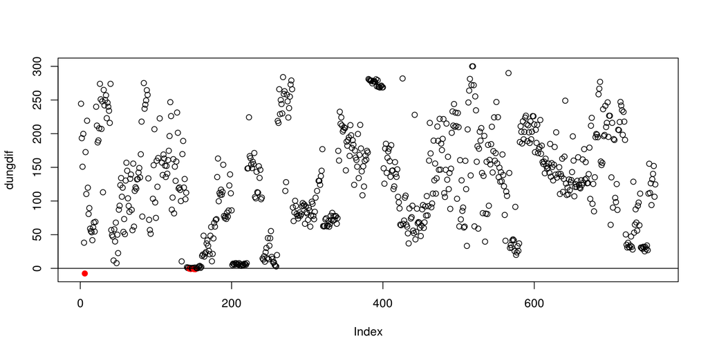

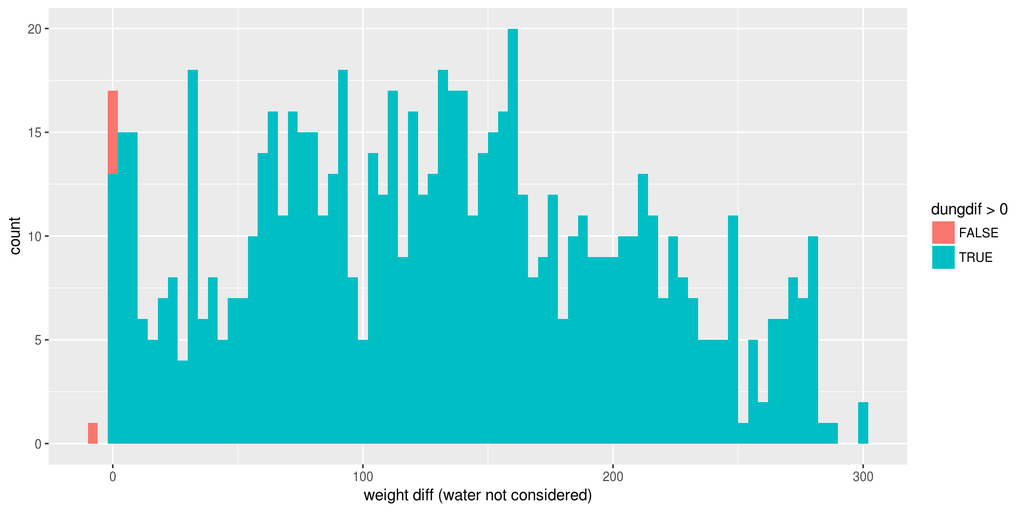

Dung increased during experiment, there was **NO** removal, but addition of dung!  
Percentage of experiments with weight increase: 0.66%

| codigo_parcela | manejo | unidad | no_unidad | initial_dung | final_dung_wet |
| --- | --- | --- | --- | --- | --- |
| ARG01Ext | Int | Exp | 6 | 297.5 | 305.13 |
| CAN01Ext | Int | Exp | 4 | 300 | 300.48 |
| CAN01Ext | Int | Exp | 6 | 300 | 300.97 |
| CAN01Ext | Int | Exp | 10 | 300 | 301.05 |
| CAN01Int | Ext | Exp | 2 | 300 | 301.31 |

In Canadian experiments the difference might be due to method inaccuracy (soil crumbs not well brushed enough etc.)

**This percentage is even higher if we consider water loss:**

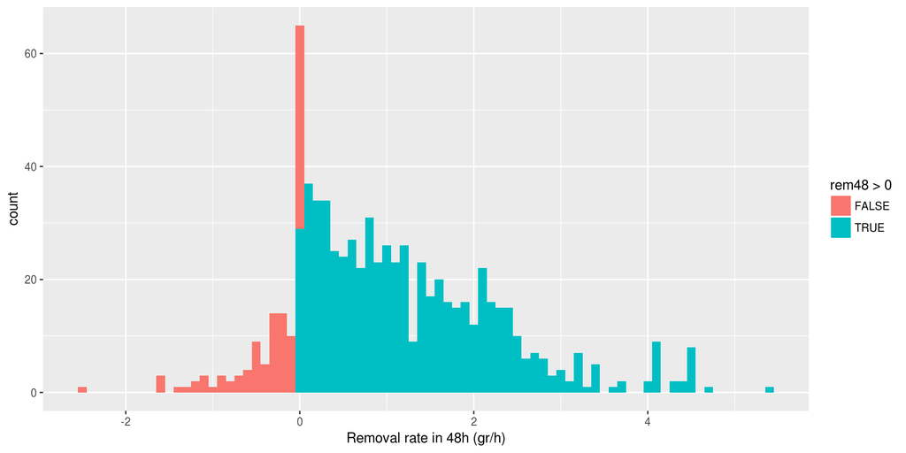

Percentage of experiments with weight increase: 14.74%

Table **only showing experiments with negative** removal rate (=*increase of weight*)

| codigo_parcela | manejo | unidad | no_unidad | initial_dung | final_dung_wet | H2O.loss | rem48 |
| --- | --- | --- | --- | --- | --- | --- | --- |
| ARG01Ext | Int | Exp | 5 | 298.3 | 260.17 | 113.976 | -1.580125 |
| ARG01Ext | Int | Exp | 6 | 297.5 | 305.13 | 113.976 | -2.53345833333333 |
| ARG01Ext | Int | Exp | 8 | 301.9 | 191.5 | 113.976 | -0.0745000000000005 |
| ARG01Int | Ext | Exp | 4 | 295.6 | 240.43 | 56.348 | -0.0245416666666666 |
| ARG01Int | Ext | Exp | 5 | 304.1 | 250.53 | 56.348 | -0.0578750000000004 |
| ARG01Int | Ext | Exp | 6 | 294.1 | 252.27 | 56.348 | -0.302458333333334 |
| ARG01Int | Ext | Exp | 9 | 304.1 | 249.43 | 56.348 | -0.0349583333333333 |
| AUS01Ext | Int | Exp | 10 | 300 | 187 | 138.6 | -0.533333333333334 |
| AUS02Ext | Int | Exp | 4 | 305.1 | 293.4 | 12.326 | -0.0130416666666662 |
| AUS02Ext | Int | Exp | 8 | 299.4 | 291.63 | 12.326 | -0.0949166666666675 |

[output cut: 102 more lines]

## METHOD 2

*dry.rem48 = (initial_dung_dry – final_dung_dry) / 48h*  
*initial_dung_dry = initial_dung_wet * (1 – water_proportion)*  
*water_proportion = final_dung_wet – final_dung_dry*

## Removal according to treatment

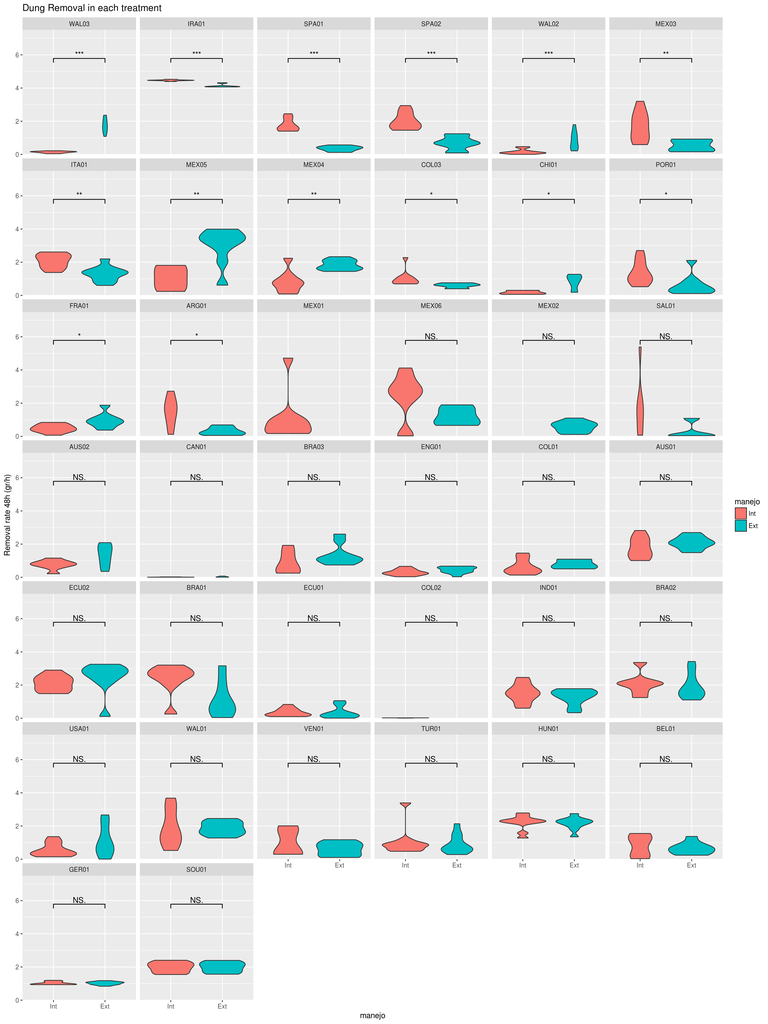

[output not shown]

[output cut: 24 more lines]

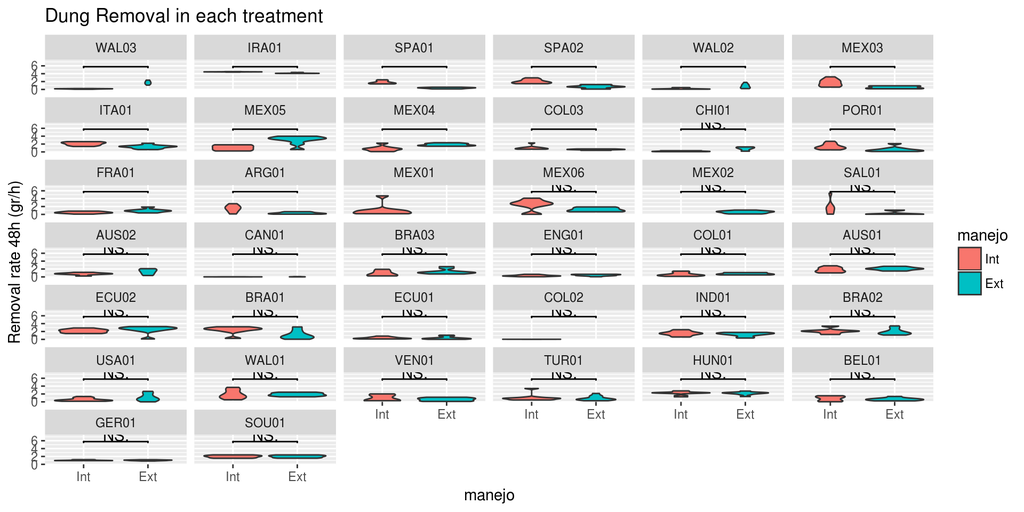